# Visualización I

Análisis exploratorio de Datos (AED)

Fecha de publicación

24 de abril de 2026

# Plan del día

Hoy vamoa a construir visualizaciones desde cero usando la **la gramática de gráficos de** **`ggplot2`**, aplicada a datos reales del [proyecto V-Dem](https://github.com/vdeminstitute/vdemdata) sobre democracia en América del Sur. Vamos a estrucutrar la clase en tres partes:

1. ¿Qué es visualizar? Datos, estéticas y la lógica de capas.
2. Recorrido por los componentes de la gramática de gráficos.
3. Análisis Exploratorias de Datos *(EDA)* vs. Comunicación de ideas y resultados.

### Librerías

En esta celda verificamos si `pacman` está instalado en el entorno. Si no lo está, lo instalamos automáticamente.

`pacman` es una librería que facilita la gestión de paquetes asegurando que todo se importe en orden y se instale de ser necesario. En particular, la función `p_load_gh` descarga e instala un repositorio directamente desde GitHub.

```r
# Instalamos pacman si no lo tenemos instalado
if (!require("pacman")) install.packages("pacman")

# De acá sale la BD que vamos a usar (Variaties of DEMocracy data)
pacman::p_load_gh("vdeminstitute/vdemdata")
pacman::p_load(
  tidyverse, # los de siempre
  janitor, # idem
  patchwork, # para combinar más de un gráficos
  scales # para configurar ejes
)
```

## ¿Qué quiere decir visualizar?

**Visualizar es codificar valores de datos en atributos visuales** (color, forma, tamaño, posición) para que el ojo humano pueda percibir patrones, tendencias y relaciones en los datos que no son evidentes a simple vista.

En términos del `tidyverse` hablamos de mapear variables (columnas de una tabla) a atributos visuales, comúnmente conocidos como `aesthetics`.

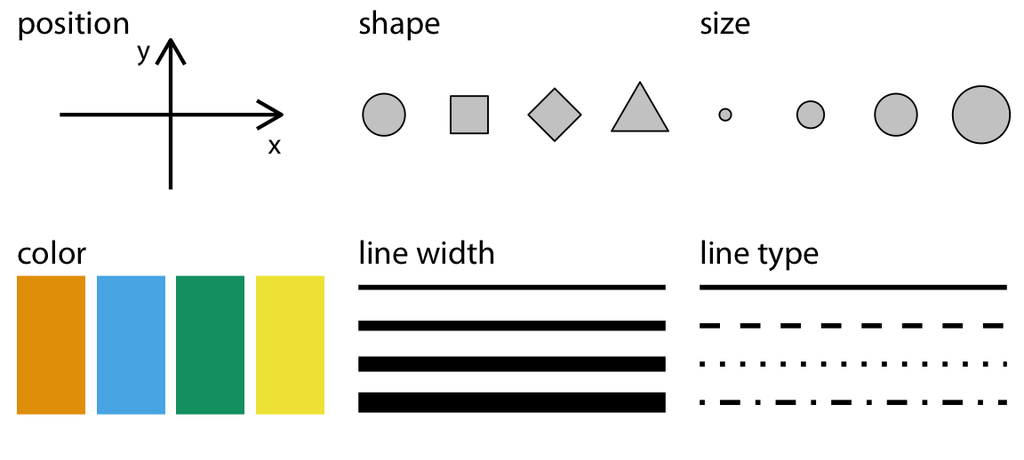

Atributos visuales (*`aesthetics`*) más utilizados (de Fundamentals of Data Visualization, Claus O. Wilke)

Vamos a ver que **la elección del atributo correcto depende del tipo de variable** (continua, discreta, ordinal) **y de la historia que queremos contar.**

**Tip**

No todos los atributos visuales son igual de efectivos para transmitir información cuantitativa. **La posición (eje x/y) es la más precisa, seguida por longitud y área. El color es muy efectivo para variables categóricas, pero puede engañar con variables continuas si no se elige bien la paleta.**

### Gramática de los gráficos en el `tidyverse`

En `ggplot2` los gráficos se construyen en **capas**, de la más elemental a la más superficial.

1. **Datos** → la tabla con la información a graficar, en general, en formato *long* ya que los mapeos se hacen a variables (columnas).
2. **Mapeos estéticos →** cómo se asignan variables a atributos visuales.
3. **Objetos geométricos** → los tipos de gráficos visuales (puntos, líneas, barras, etc).
4. **Transformaciones estadísticas** → transfornaciones que resumen los datos.
5. **Ajustes de posición** **y escalas** → dónde y cómo se etiquetan los elementos.
6. **Sistemas de coordenadas y facetas** → la proyección y las subdivisiones del gráfico.

Los gráficos se construyen apilando estas capas, **siendo las primeras tres imprescindibles para construir cualquier figura**. El resto de las capas tienen valores defecto que de elegirlos enriquecen y refinan lo que queremos contar. Para apilar las capas se usa el operador `+`.

```r
ggplot(data = <DATOS>, mapping = aes(<MAPEOS>)) +
  geom_<GEOMETRÍA>() +
  stat_<TRANSFORMACIÓN>() +
  scale_<ESCALA>() +
  coord_<COORDENADA>() +
  facet_<FACETA>()
```

#### a. Datos

Hoy vamos a trabajar con datos del proyecto **V-Dem** ([*Varieties of Democracy*](https://github.com/vdeminstitute/vdemdata)), uno de los conjuntos de datos más completos sobre democracia, autoritarismo y derechos humanos en el mundo, con cobertura desde 1789 hasta la actualidad.

En concreto nos vamos a enfocar en **América del Sur** y en los siguientes índices:

- `v2x_polyarchy`: **Índice de Democracia Electoral (EDI)** → mide en qué medida el poder ejecutivo emerge de elecciones limpias y libres. Es una variable continua que se mide entre 0 y 1.
- `v2x_libdem`: **Índice de Democracia Liberal (LDI)** → agrega al EDI la protección de libertades civiles y límites al poder ejecutivo. También es una variable continua en el intervalo [0,1].

```r
paises_sudamerica <- c(
    "Argentina", "Bolivia", "Brazil", "Chile", "Colombia",
  "Ecuador", "Paraguay", "Peru", "Uruguay", "Venezuela"
)
# Filtramos vdem que es inmenso (formato long de ~28k observaciones y ~4,5 k variables)
sudamerica <- vdemdata::vdem |>
  filter(country_name %in% paises_sudamerica) |>
  select(
    country_name,
    year,
    v2x_polyarchy,   # Índice de Democracia Electoral
    v2x_libdem,      # Índice de Democracia Liberal
    v2x_partipdem,   # Índice de Democracia Participativa
    v2x_egaldem,     # Índice de Democracia Igualitaria
    e_pop,           # Población (variable de contexto)
    e_gdppc          # PBI per cápita (variable de contexto)
  )
#|>
 # drop_na(v2x_polyarchy:v2x_libdem)

# Investigamos de qué tratan las variables
variables <- names(sudamerica)[3:ncol(sudamerica)]
variables_description <- variables |>
  vdemdata::var_info() |>
  as.data.frame() |>
  select(
    tag, name, scale, vartype, question, clarification, years, cy_aggregation
  )
variables_description |>
  select(
    tag,years, vartype, question, clarification, cy_aggregation, scale
  )
```

| tag | years | vartype | question | clarification | cy_aggregation | scale |
| --- | --- | --- | --- | --- | --- | --- |
| v2x_libdem | 1789-2025 | D | To what extent is the ideal of liberal democracy achieved? | The liberal principle of democracy emphasizes the importance of protecting individual and minority rights against the tyranny of the state and the tyranny of the majority. The liberal model takes a "n… | Day-weighted mean | Interval, from low to high (0-1). |
| e_gdppc | 1789-2019 | E | NA | Point estimate from latent variable model of Gross Domestic Product Per Capita based on a number of sources. For details, see the citation. | NA | NA |
| v2x_polyarchy | 1789-2025 | D | To what extent is the ideal of electoral democracy in its fullest sense achieved? | The electoral principle of democracy seeks to embody the core value of making rulers responsive to citizens, achieved through electoral competition for the electorate's approval under circumstances wh… | Day-weighted mean | Interval, from low to high (0-1). |
| v2x_partipdem | 1789-2025 | D | To what extent is the ideal of participatory democracy achieved? | The participatory principle of democracy emphasizes active participation by citizens in all political processes, electoral and non-electoral. It is motivated by uneasiness about a bedrock practice of … | Day-weighted mean | Interval, from low to high (0-1). |
| e_pop | 1789-2019 | E | NA | Point estimate from latent variable model of Population based on a number of sources. For details, see the citation. | NA | NA |
| v2x_egaldem | 1900-2025 | D | To what extent is the ideal of egalitarian democracy achieved? | The egalitarian principle of democracy holds that material and immaterial inequalities inhibit the exercise of formal rights and liberties, and diminish the ability of citizens from all social groups … | Day-weighted mean | Interval, from low to high (0-1). |

```r
sudamerica <- sudamerica |>
  # Renombramos para mayor claridad en los gráfico
  rename(
    pais       = country_name,
    edi        = v2x_polyarchy,
    ldi        = v2x_libdem,
    dem_part   = v2x_partipdem,
    dem_egal   = v2x_egaldem,
    pbi_pc     = e_gdppc
  ) |>
  # Las uniades de población son cada 1000 habs, queremos unitario (desp transformamos)
  mutate(e_pop = e_pop * 1000)
head(sudamerica, 20)
```

|  | pais | year | edi | ldi | dem_part | dem_egal | e_pop | pbi_pc |
| --- | --- | --- | --- | --- | --- | --- | --- | --- |
| 1 | Colombia | 1789 | NA | NA | NA | NA | NA | NA |
| 2 | Colombia | 1790 | NA | NA | NA | NA | NA | NA |
| 3 | Colombia | 1791 | NA | NA | NA | NA | NA | NA |
| 4 | Colombia | 1792 | NA | NA | NA | NA | NA | NA |
| 5 | Colombia | 1793 | NA | NA | NA | NA | NA | NA |
| 6 | Colombia | 1794 | NA | NA | NA | NA | NA | NA |
| 7 | Colombia | 1795 | NA | NA | NA | NA | NA | NA |
| 8 | Colombia | 1796 | NA | NA | NA | NA | NA | NA |
| 9 | Colombia | 1797 | NA | NA | NA | NA | NA | NA |
| 10 | Colombia | 1798 | NA | NA | NA | NA | NA | NA |

[output cut: 10 more lines]

Lo primero que notamos es que hay observaciones que no tienen valores para algunos de los indicadores para ciertos años. Es conveniente tener una noción de los rangos que toman nuestras variables.

```r
# Rango temporal y valores de los índices
sudamerica |>
  group_by(pais) |>
  summarise(
    anio_min  = min(year),
    anio_max  = max(year),
    pbi_pc_max = round(max(pbi_pc, na.rm = TRUE), 3),
    ldi_media = round(mean(ldi, na.rm = TRUE), 3),
    edi_mean   = round(mean(edi, na.rm = TRUE), 3),
    .groups = "drop"
  )
```

| pais | anio_min | anio_max | pbi_pc_max | ldi_media | edi_mean |
| --- | --- | --- | --- | --- | --- |
| Argentina | 1789 | 2025 | 46.477 | 0.266 | 0.346 |
| Bolivia | 1825 | 2025 | 13.750 | 0.144 | 0.265 |
| Brazil | 1789 | 2025 | 29.178 | 0.212 | 0.285 |
| Chile | 1789 | 2025 | 53.121 | 0.272 | 0.326 |
| Colombia | 1789 | 2025 | 30.629 | 0.227 | 0.303 |
| Ecuador | 1830 | 2025 | 23.029 | 0.176 | 0.308 |
| Paraguay | 1811 | 2025 | 20.022 | 0.108 | 0.205 |
| Peru | 1789 | 2025 | 24.878 | 0.203 | 0.311 |
| Uruguay | 1825 | 2025 | 47.918 | 0.408 | 0.485 |
| Venezuela | 1789 | 2025 | 35.770 | 0.167 | 0.230 |

```r
# Calculamos los rangos para cada variables acotando a los límites de los países con menos datos
variables_id = c("edi", "ldi", "dem_part", "dem_egal", "pbi_pc")
rangos_sudamerica <- sudamerica |>
  pivot_longer(cols = all_of(variables_id), names_to = "variable") |>
  filter(!is.na(value)) |>
  group_by(variable, pais) |>
  summarize(min_p = min(year), max_p = max(year), .groups = "drop") |>
  group_by(variable) |>
  summarize(min = max(min_p), max = min(max_p))
rangos_sudamerica
```

| variable | min | max |
| --- | --- | --- |
| dem_egal | 1900 | 2025 |
| dem_part | 1830 | 2025 |
| edi | 1830 | 2025 |
| ldi | 1830 | 2025 |
| pbi_pc | 1830 | 2019 |

**Tip**

`ggplot2` requiere que los datos estén en formato *long* (una variable por columna, una observación por fila). Si tuviéramos los índices como columnas separadas para distintos años (*wide*), necesitaríamos usar `pivot_longer()` antes de graficar.

#### b. Mapas estéticos (`aes`)

Los mapeos estéticos conectan **variables del la tabla de datos** con **propiedades visuales**. Se definen dentro de `aes()`. Cuando una propiedad visual es constante, es decir, no depende de los datos, se define **fuera** de `aes()`. Veamos algunos ejemplos.

Veamos el EDI (**índice de democracia electoral**) a lo largo del tiempo para Argentina (esto es una serie temporal —un valor numérico para distintos instantes en el tiempo).

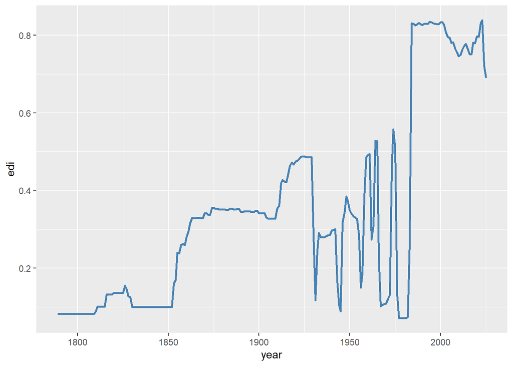

```r
# Filtramos solo Argentina para el primer ejemplo
argentina <- sudamerica |> filter(pais == "Argentina")

# Armamos únicamente las primeras tres capas (datos, mapeo y geometría)
ggplot(data = argentina, mapping = aes(x = year, y = edi)) +
  geom_line(color = "steelblue", linewidth = 1)
```

Acá lo relevante es notar que `color` y `linewidth` son propiedades fijas, mientras que a `x` e `y` se les asignan mapeos a variables de los datos.

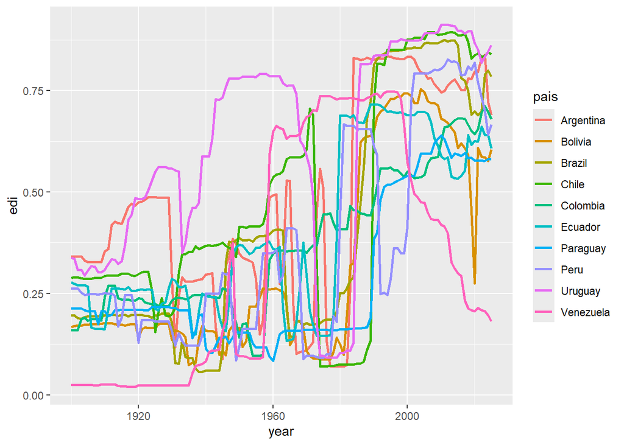

```r
# Datos del siglo XX en adelante para mayor legibilidad
sudamerica_reciente <- sudamerica |> filter(year >= 1900)

ggplot(
  data = sudamerica_reciente,
  mapping = aes(x = year, y = edi, color = pais)
) +
  geom_line(linewidth = 1, alpha = 1)
```

En este ejemplo incluimos a los 10 países y mapeamos `pais` al color. Para esto `ggplot2` asigna automáticamente una paleta y genera una leyenda.

**¿Qué interpretamos de este gráfico?**

Con 10 países superpuestos el gráfico se vuelve muy difícil de leer. Esto es un ejemplo de *overplotting* en series temporales —un problema típico del AED que resolveremos con facetas más adelante.

Antes de seguir a la siguiente capa veamos un último ejemplo.

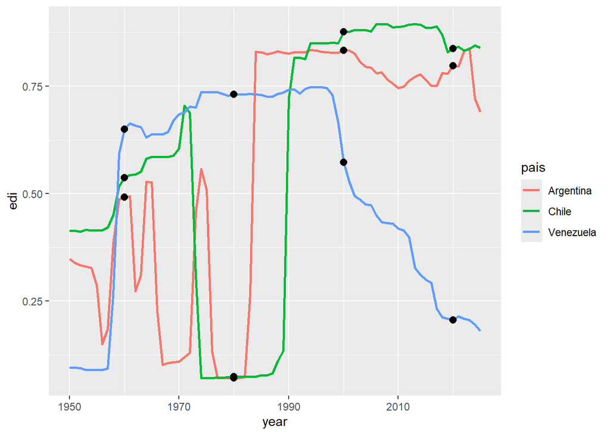

```r
# Filtramos tres países para un ejemplo más claro
tres_paises <- sudamerica |>
  filter(
    pais %in% c("Argentina", "Chile", "Venezuela"),
    year >= 1950
  )

# Los puntos en el gráfico son del mismo color para todas las series
ggplot(data = tres_paises, mapping = aes(x = year, y = edi)) +
  geom_line(aes(color = pais), linewidth = 0.9) +
  geom_point(
    data = tres_paises |> filter(year %% 20 == 0),  # Un punto cada 20 años
    size = 2.5
  )
```

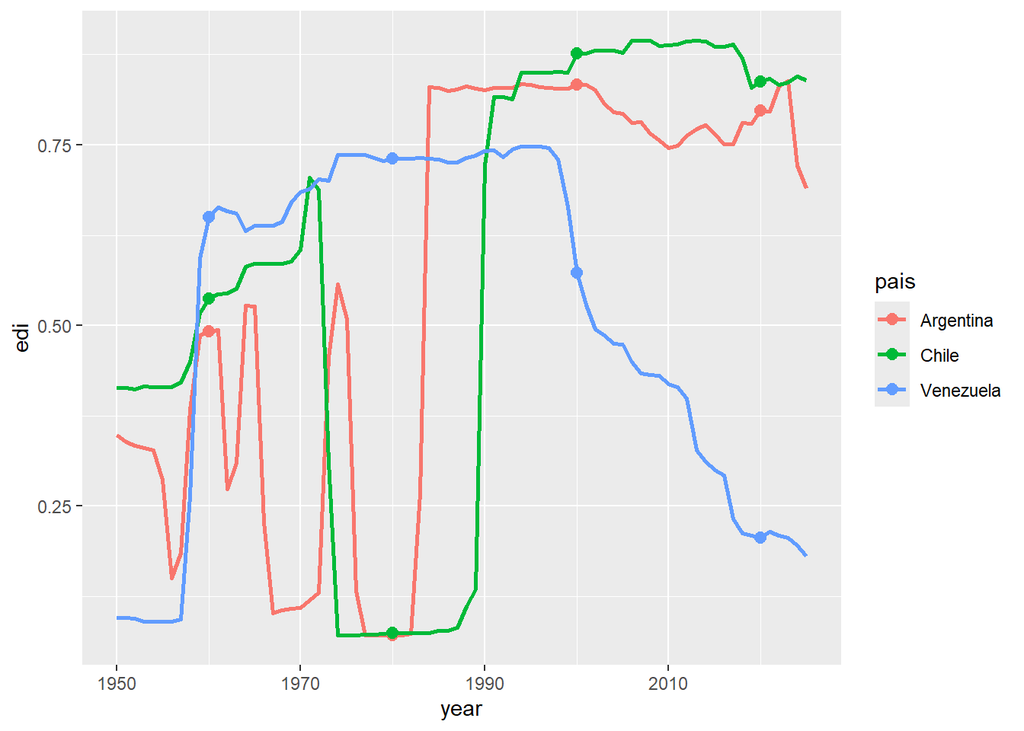

```r
# Todas las geometrías heredan el mapeo de color en este otro caso
ggplot(data = tres_paises, mapping = aes(x = year, y = edi, color = pais)) +
  geom_line(linewidth = 0.9) +
  geom_point(
    data = tres_paises |> filter(year %% 20 == 0),  # Un punto cada 20 años
    size = 2.5
  )
```

**Importante**

Los mapeos definidos en el primer nivel `ggplot()` son **globales** y se aplican a todas las capas. Pero los definidos dentro de un `geom_*()` son **locales** y sobrescriben o extienden los globales solo para esa capa.

Los mapeos locales son particularmente útiles para destacar subconjuntos específicos de los datos o para combinar geometrías que requieren estéticas distintas.

#### c. Objetos geométricos (`geom_*`)

Los objetos geométricos son las **formas visuales** que representan los datos: puntos, líneas, barras, áreas, etc.

La elección del `geom_*` correcto depende del tipo de datos y la pregunta que busquemos responder. Veamos algunos ejemplos.

**¿Existe una relación entre el PBI per cápita y el nivel de democracia electoral (EDI) en América del Sur para el año 2019?**

Para hacer una visualización que nos de información para responder esta pregunta podría ser útil un **diagrama de dispersión**.

```r
# Tomamos el año reciente para el scatter
sudamerica_last_year <- sudamerica |>
  # Seleccionamos el último año en el cual estan definidas las dos variables
  # Recordemos que rangos es una tabla con variables de año
  filter(
    year == (rangos_sudamerica |> filter(variable=="pbi_pc")|> pull(max))|
    year == (rangos_sudamerica |> filter(variable=="edi")|> pull(max))
  ) |>
  drop_na(pbi_pc, edi)

last_year<- min(
  (rangos_sudamerica |> filter(variable=="edi")|> pull(max)),
  (rangos_sudamerica |> filter(variable=="pbi_pc")|> pull(max))
)

sudamerica_last_year
```

| pais | year | edi | ldi | dem_part | dem_egal | e_pop | pbi_pc |
| --- | --- | --- | --- | --- | --- | --- | --- |
| Colombia | 2019 | 0.651 | 0.511 | 0.460 | 0.378 | 5245057 | 30.629 |
| Brazil | 2019 | 0.691 | 0.528 | 0.436 | 0.395 | 22285340 | 25.458 |
| Bolivia | 2019 | 0.456 | 0.241 | 0.341 | 0.294 | 1208564 | 13.750 |
| Peru | 2019 | 0.801 | 0.694 | 0.588 | 0.514 | 3392069 | 24.750 |
| Argentina | 2019 | 0.779 | 0.618 | 0.517 | 0.612 | 4715714 | 42.896 |
| Venezuela | 2019 | 0.209 | 0.060 | 0.157 | 0.124 | 2873734 | 12.790 |
| Chile | 2019 | 0.829 | 0.761 | 0.559 | 0.613 | 1986680 | 53.121 |
| Ecuador | 2019 | 0.617 | 0.446 | 0.425 | 0.406 | 1809174 | 21.463 |
| Uruguay | 2019 | 0.896 | 0.836 | 0.733 | 0.792 | 364963 | 47.918 |
| Paraguay | 2019 | 0.585 | 0.420 | 0.363 | 0.242 | 742528 | 19.990 |

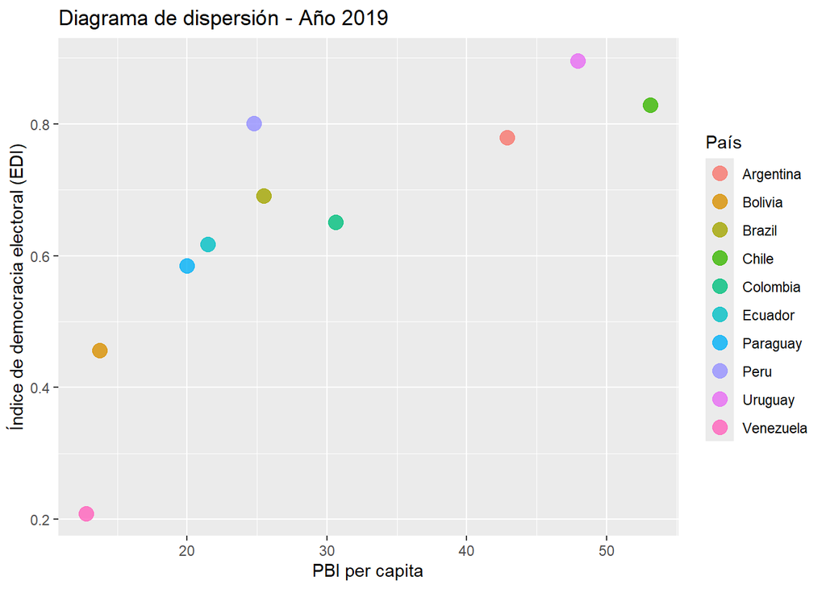

```r
ggplot(data = sudamerica_last_year,
       mapping = aes(x = pbi_pc, y = edi, colour = pais)) +
  geom_point(size = 4, alpha = 0.8) +
  # "labs" es abreviatura de labels: etiquetas --> asignamos una por cada mapa y aquellas que querramos sumar (título, subt, etc.)
  labs(
    title = paste0("Diagrama de dispersión - Año ",last_year),
    x="PBI per capita",
    y="Índice de democracia electoral (EDI)",
    color="País"
  )
```

Para las **series temporales** es natural el uso de `geom_line` tal como vimos más arriba.

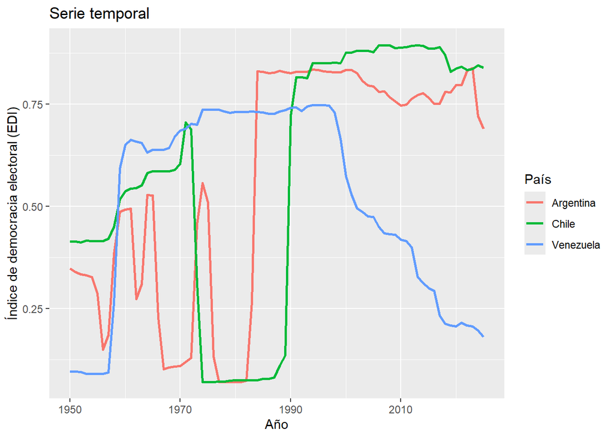

```r
ggplot(data = tres_paises,
       mapping = aes(x = year, y = edi, colour = pais)) +
  geom_line(linewidth = 1)+
  labs(
    title="Serie temporal",
    x='Año',
    y="Índice de democracia electoral (EDI)",
    color="País"
  )
```

Podemos superponer capas del mismo o distinto tipo. Eso puede ser útil si queremos **destacar sucesos particulares en la serie**.

Por ejemplo, acá añadimos puntos en los años de quiebres democráticos conocidos en Chile y Argentina para enriquecer la visualización.

```r
# Definimos algunos años de quiebre democrático (golpes militares)
arg_chile <- sudamerica |> filter(
    pais %in% c("Argentina", "Chile"),
    year >= 1920
  )
quiebres <- arg_chile |>
  filter(
    (year %in% c(1930, 1943, 1955, 1962, 1966, 1976)) |
    (year == 1973)
  )
quiebres
```

| pais | year | edi | ldi | dem_part | dem_egal | e_pop | pbi_pc |
| --- | --- | --- | --- | --- | --- | --- | --- |
| Argentina | 1930 | 0.284 | 0.249 | 0.210 | 0.189 | 1216048 | 15.428 |
| Argentina | 1943 | 0.169 | 0.152 | 0.158 | 0.147 | 1513167 | 16.205 |
| Argentina | 1955 | 0.286 | 0.150 | 0.221 | 0.233 | 1931857 | 17.510 |
| Argentina | 1962 | 0.274 | 0.205 | 0.210 | 0.250 | 2230073 | 21.188 |
| Argentina | 1966 | 0.228 | 0.201 | 0.196 | 0.196 | 2376524 | 23.724 |
| Argentina | 1973 | 0.456 | 0.277 | 0.301 | 0.293 | 2640332 | 29.339 |
| Argentina | 1976 | 0.133 | 0.066 | 0.126 | 0.132 | 2766912 | 30.106 |
| Chile | 1930 | 0.198 | 0.177 | 0.090 | 0.057 | 438455 | 9.472 |
| Chile | 1943 | 0.369 | 0.283 | 0.191 | 0.151 | 544940 | 10.581 |
| Chile | 1955 | 0.415 | 0.294 | 0.212 | 0.168 | 731130 | 13.270 |

[output cut: 4 more lines]

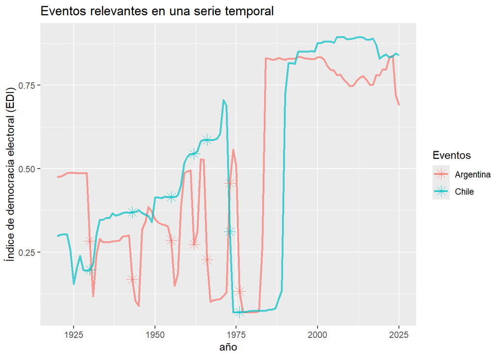

```r
ggplot(
  data = arg_chile, aes(x = year, y = edi, colour = pais)
  ) +
  geom_line(linewidth = 0.9, alpha = 0.7) +
  # Capa adicional: resaltamos puntos de interés con datos propios
  geom_point(
    data = quiebres,
    aes(colour = pais), # desagregamos el color por país, igual que en el otro nivel
    size = 3.5, shape = 8
  )+
  labs(
    title="Eventos relevantes en una serie temporal",
    y="Índice de democracia electoral (EDI)",
    x="año",
    color="Eventos"
  )
```

**¿Cómo se distribuyen los valores del EDI en América del Sur a lo largo del siglo XX y XXI?**

Para hablar de distribuciones hay una gran variedad de alternativas. Las clásicas son **histogramas, densidades y boxplot.**

```r
# Esto era sudamerica a partir de 1900
sudamerica_reciente
```

| pais | year | edi | ldi | dem_part | dem_egal | pbi_pc |
| --- | --- | --- | --- | --- | --- | --- |
| Colombia | 1900 | 0.160 | 0.081 | 0.067 | 0.036 | 2.490 |
| Colombia | 1901 | 0.160 | 0.081 | 0.067 | 0.036 | 2.479 |
| Colombia | 1902 | 0.160 | 0.081 | 0.067 | 0.036 | 2.473 |
| Colombia | 1903 | 0.187 | 0.156 | 0.072 | 0.041 | 2.467 |
| Colombia | 1904 | 0.191 | 0.154 | 0.073 | 0.041 | 2.462 |
| Colombia | 1905 | 0.183 | 0.142 | 0.071 | 0.040 | 2.471 |
| Colombia | 1906 | 0.187 | 0.143 | 0.072 | 0.040 | 2.499 |
| Colombia | 1907 | 0.187 | 0.143 | 0.072 | 0.040 | 2.558 |
| Colombia | 1908 | 0.187 | 0.143 | 0.072 | 0.040 | 2.640 |
| Colombia | 1909 | 0.184 | 0.142 | 0.071 | 0.040 | 2.719 |

[output cut: 1250 more lines]

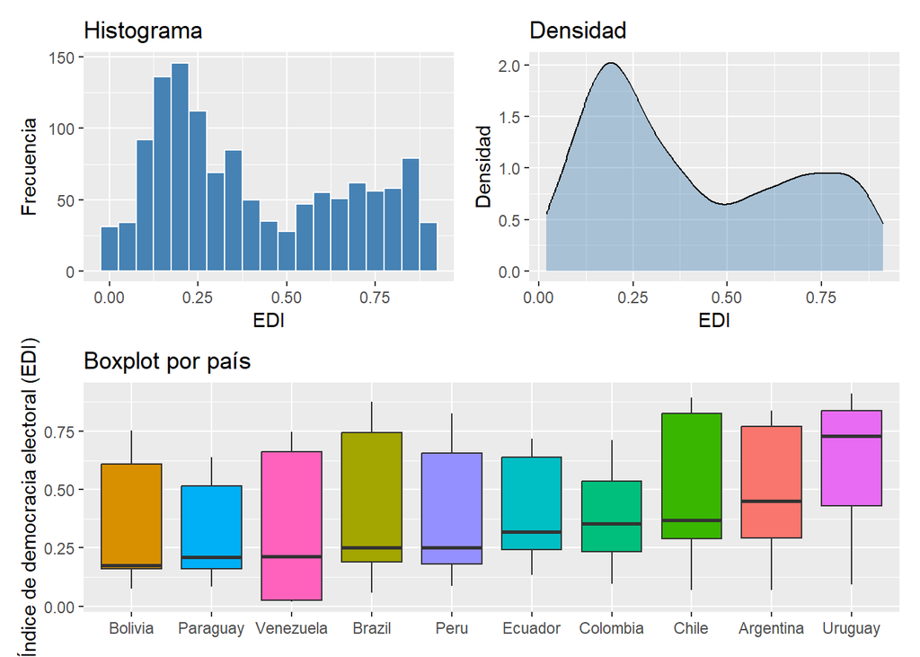

```r
# Histograma
p_hist <- ggplot(sudamerica_reciente, aes(x = edi)) +
  geom_histogram(binwidth = 0.05, fill = "steelblue", colour = "white") +
  labs(title = "Histograma", x = "EDI", y = "Frecuencia")

# Densidad
p_dens <- ggplot(sudamerica_reciente, aes(x = edi)) +
  geom_density(fill = "steelblue", alpha = 0.4) +
# p_dens <- ggplot(sudamerica_reciente, aes(x = edi, fill=pais)) +
  # geom_density(alpha = 0.4) + #DESCOMENTAR PARA VER DIF
  labs(title = "Densidad", x = "EDI", y = "Densidad")

# Boxplot por país
p_box <- ggplot(sudamerica_reciente, aes(
  # devuelve un factor de scores (la mediana) donde cada nivel es un pais y el orden viene dado en orden creciente
  x = reorder(pais, edi, median),
  y = edi, fill = pais)) +
  geom_boxplot(show.legend = FALSE) +
  # coord_flip() + #DESCOMENTAR PARA VER DIF
  labs(title = "Boxplot por país", x = NULL, y = "Índice de democracia electoral (EDI)")

# Ensamblamos con patchwork (más adelante charlamos sobre la sintaxis)
(p_hist + p_dens) / p_box
```

Teniendo en cuenta que se tratan de distribuciones a lo largo de los años, resulta evidente notar que, en general, los países del cono sur no presentan una gran estabilidad democrática, al menos no para el período que contemplamos.

Esto se nota viendo la gran dispersión en las distribuciones. En particular, se destacan Bolivia y Uruguay por ser los países más extremos en estas distribuciones. La dispersión la vemos, por ejemplo, en los “box” que representan el IQR (*Interquartile range*), es decir, el rango comprendido entre el 25 y 75 %.

Si quisiéramos indagar más sobre el tema deberíamos desglosar los datos por país y ver períodos más estrechos de tiempo.

#### d. Transformaciones estadísticas

Las transformaciones estadísticas calculan valores derivados de los datos *antes* de dibujarlos. Muchos `geom_*` tienen una `stat_*` implícita (por ejemplo, `geom_histogram` usa `stat_bin`). También podemos llamarlas explícitamente.

**¿Cuál es la tendencia general del EDI en toda la región?**

A veces es conviente suavizar los datos para ver si existe una tendencia clara.

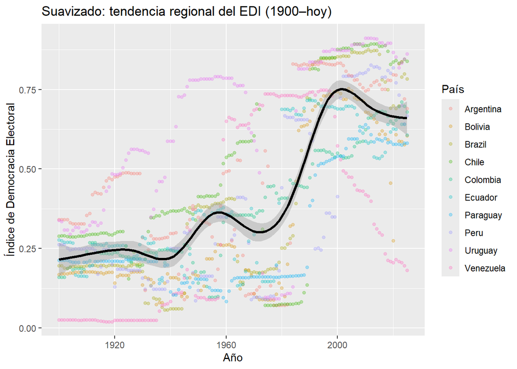

```r
ggplot(sudamerica_reciente, aes(x = year, y = edi)) +
  geom_point(aes(colour = pais), alpha = 0.3, size = 1.2) +
  # stat implícita: loess (suavizado local). Se puede cambiar con method =
  geom_smooth(colour = "black", linewidth = 1.2, se = TRUE) +
  labs(
    title = "Suavizado: tendencia regional del EDI (1900–hoy)",
    x = "Año", y = "Índice de Democracia Electoral",
    color="País"
  )
```

```r
# ggplot(sudamerica_reciente, aes(x = year, y = edi)) +
#   geom_point(aes(colour = pais), alpha = 0.3, size = 1.2) +
#   # stat implícita: loess (suavizado local). Se puede cambiar con method =
#   geom_smooth(aes(colour = pais), linewidth = 1.2, se = TRUE) +
#   labs(
#     title = "Suavizado: tendencia regional del EDI (1900–hoy)",
#     x = "Año", y = "Índice de Democracia Electoral",
#     color="País"
#   )
```

**Advertencia**

Siempre que se grafique una curva suavizada es importante superponerla a los datos crudos, para ver, al menos de forma cualitativa, si la tendencia es clara.

Por ejemplo, en el caso de arriba, al hacer un suavizado sobre todos los países juntos la curva no pareciera ser una tendencia evidente de los procesos que en verdad sucedieron. Prueben ver la versión desagregada por país (descomentar gráfico de abajo).

Otra forma de agregar los datos sin perder la serie temporal es, en lugar de mostrar todos los puntos, calcular la mediana entre todos los paises y el rango (en términos de cuantiles) por año para toda la región.

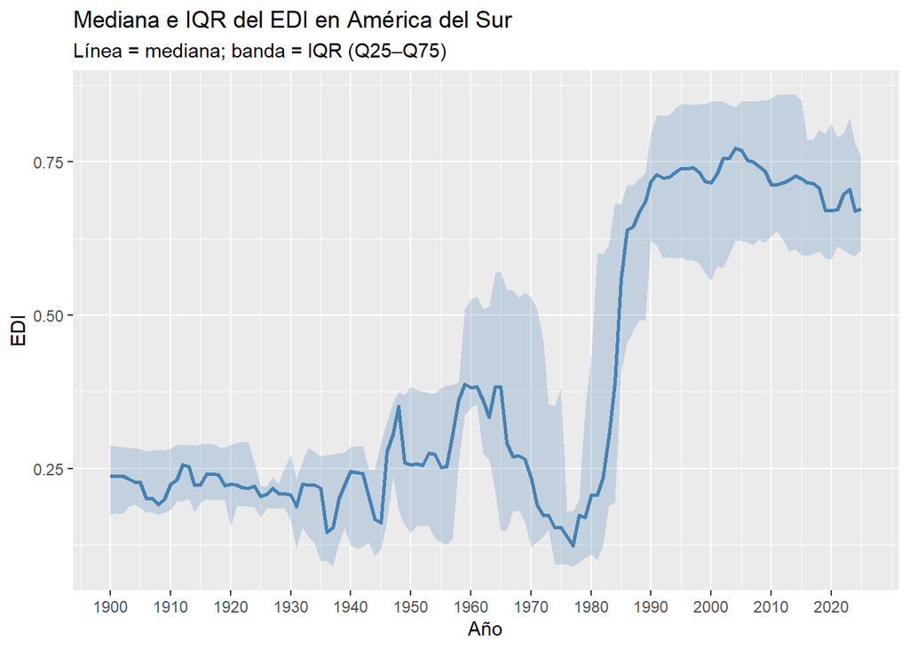

```r
# stat_summary calcula fun (central) y fun.min/fun.max (rango)
ggplot(sudamerica_reciente, aes(x = year, y = edi)) +
  stat_summary(
    fun     = median,
    fun.min = function(x) quantile(x, 0.25),
    fun.max = function(x) quantile(x, 0.75),
    geom    = "ribbon", # el sombreado
    alpha   = 0.25,
    fill    = "steelblue"
  ) +
  stat_summary(
    fun  = median,
    geom = "line",
    colour = "steelblue", linewidth = 1
  ) +
  scale_x_continuous( #lo vemos en un ratito en profundidad
    breaks = seq(
      min(sudamerica_reciente$year), max(sudamerica_reciente$year), by = 10
    )
  ) +
  labs(
    title    = "Mediana e IQR del EDI en América del Sur",
    subtitle = "Línea = mediana; banda = IQR (Q25–Q75)",
    x = "Año", y = "EDI"
  )
```

De acá se observa claramente que entre los 80 y 90 hubo un claro repunte del índice democrático a nivel regional.